# Taller 1 analisis avanzado de datos

Hector Rojas y Jorge Henao

2023-03-11

```r
suppressMessages(library(tidyverse))
suppressMessages(library(ggplot2))
suppressMessages(library(Metrics))
suppressMessages(library(palmerpenguins))
suppressMessages(library(scales))
suppressMessages(library(corrplot))
suppressMessages(install.packages("Metrics"))
```

```r
data <- read.delim2(file="taller1.txt", header=TRUE, sep = ",", dec = ".")
```

vista previa de los datos para observar como fueron cargados.

```r
head(data[,1:10], n = 10)
```

```
##            y          V1         V2          V3          V4          V5
## 1  -2.241255 -0.56047565  0.6198501 -0.48313507 -0.21362309 -0.63271355
## 2  -3.525571 -0.23017749 -0.7575102 -0.53134692  1.19787606  0.10917162
## 3   2.994233  1.55870831  0.8515247 -0.58768476  0.23180313 -1.56255658
## 4  -1.423401  0.07050839 -0.7479300 -0.41169787 -0.50284145 -0.04024543
## 5   6.606610  0.12928774  0.6302398  0.70918562  0.63045713 -0.03632993
## 6   5.341860  1.71506499  1.0966616  0.25639675  0.95729753 -0.27892558
## 7  -9.744859  0.46091621 -0.9884429 -1.85636059 -0.07448286 -1.29312945
## 8   3.972097 -1.26506123  1.1079950 -1.86058763 -2.67816441  1.16680081
## 9   2.953943 -0.68685285 -0.4895329 -0.02283409  1.63616439 -1.48537405
## 10 -4.957745 -0.44566197  0.2943534  0.14993875 -0.75063055 -1.47712041
##             V6          V7         V8         V9
## 1  -0.69922811  0.92823301  0.5243487 -1.1834571
## 2   0.99645153  0.35909046 -0.7420841 -0.3758021
## 3  -0.69274535  0.18675734  1.0714733 -1.4671582
## 4  -0.10348305 -0.41984544 -1.2903685 -0.2953407
## 5   0.60386606 -1.16598027  2.0981832 -0.5631464
## 6  -0.60804498 -0.27673783 -0.1785391  0.1532600
## 7   0.08486612 -0.85625783 -1.4046791  0.5039012
## 8   1.57799020  0.13942431 -1.0444683  0.2584769
## 9  -0.46365374  0.03152455 -2.0006723  0.6146975
## 10 -1.15852701 -0.33652134 -0.2042346  0.1600943
```

```r
modelData <- data.frame(data[,2:5001])
```

Dado el analisis anterior y debido a que este modelo tiene más variables que observaciones es una clara fuente de multicolinealidad lo que es llamado un modelo sobredefinido.

Punto 2:

```r
Y1 <- data$y
x <- modelData
```

Separando aleatoriamente y guardando la semilla

```r
set.seed(123)
train <- sample(nrow(data), nrow(data)*0.8)
x_train <- x[train, ]
y_train <- Y1[train]
x_test <- x[-train, ]
y_test <- Y1[-train]
```

```r
x_train <- scale(x_train)
x_test <- scale(x_test)
```

Definiendo los modelos Ridge y Lasso

```r
ridge <- glmnet::glmnet(x_train, y_train, alpha = 0  )
lasso <- glmnet::glmnet(x_train, y_train, alpha = 1)
```

seleccionando el valor de lambda que minimiza el ECM mediante validación cruzada

```r
ridge_cv <- glmnet::cv.glmnet(x_train, y_train, alpha = 0)
lasso_cv <- glmnet::cv.glmnet(x_train, y_train, alpha = 1)
```

gráfico del Mean Square Error obtenido por validación cruzada para Lasso

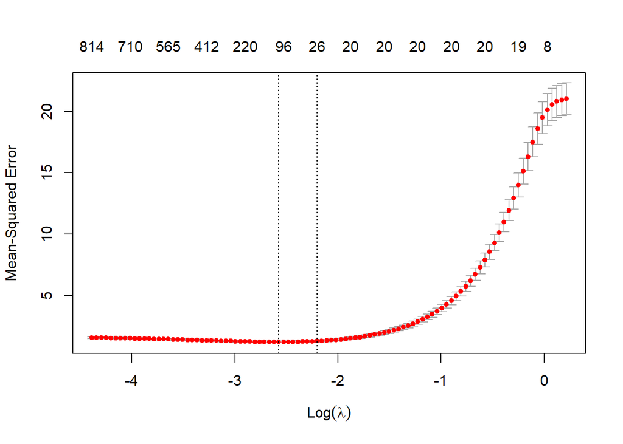

```r
plot(lasso_cv)
```

El mejor Lambda encontrado para Lasso es:

```r
paste("Mejor valor de lambda encontrado para Lasso:", lasso_cv$lambda.min)
```

```
## [1] "Mejor valor de lambda encontrado para Lasso: 0.076239726580448"
```

```r
paste("Mejor valor de lambda encontrado para Lasso + 1 desviación estándar:", lasso_cv$lambda.1se)
```

```
## [1] "Mejor valor de lambda encontrado para Lasso + 1 desviación estándar: 0.110610789387576"
```

gráfico del Mean Square Error obtenido por validación cruzada para Ridge

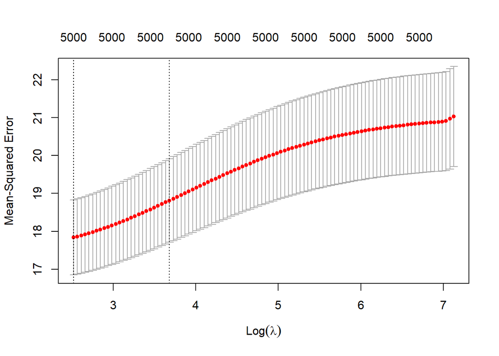

```r
plot(ridge_cv)
```

El mejor Lambda encontrado para Ridge es:

```r
paste("Mejor valor de lambda encontrado para ridge:", ridge_cv$lambda.min)
```

```
## [1] "Mejor valor de lambda encontrado para ridge: 12.4251758025735"
```

```r
paste("Mejor valor de lambda encontrado para ridge + 1 desviación estándar:", ridge_cv$lambda.1se)
```

```
## [1] "Mejor valor de lambda encontrado para ridge + 1 desviación estándar: 39.7514566265286"
```

[figure not shown]

```r
df_coeficientes_ridge <- coef(ridge) %>%
                   as.matrix() %>%
                   as_tibble(rownames = "predictor") %>%
                   rename(coeficiente_ridge = s0)

df_coeficientes_ridge %>%
  filter(predictor != "(Intercept)") %>%
  ggplot(aes(x = predictor, y = coeficiente_ridge)) +
  geom_col() +
  labs(title = "Coeficientes del modelo Ridge") +
  theme_bw() +
  theme(axis.text.x = element_text(size = 6, angle = 45))
```

Evolución de los coeficientes en función de lambda

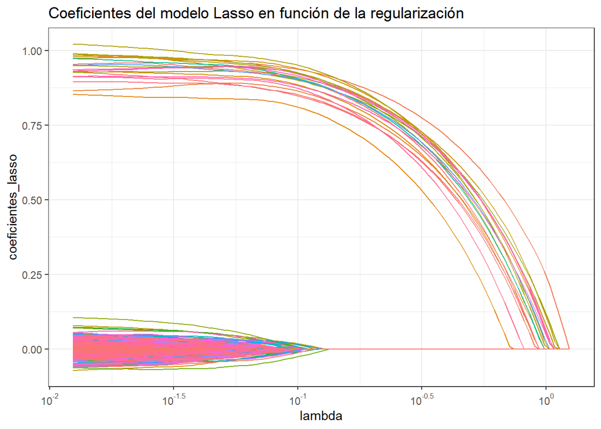

```r
# Evolución de los coeficientes en función de lambda
# ==============================================================================
regularizacion <- lasso$beta %>%
                  as.matrix() %>%
                  t() %>%
                  as_tibble() %>%
                  mutate(lambda = lasso$lambda)

regularizacion <- regularizacion %>%
                   pivot_longer(
                     cols = !lambda,
                     names_to = "predictor",
                     values_to = "coeficientes_lasso"
                   )

regularizacion %>%
  ggplot(aes(x = lambda, y = coeficientes_lasso, color = predictor)) +
  geom_line() +
  scale_x_log10(
    breaks = trans_breaks("log10", function(x) 10^x),
    labels = trans_format("log10", math_format(10^.x))
  ) +
  labs(title = "Coeficientes del modelo Lasso en función de la regularización") +
  theme_bw() +
  theme(legend.position = "none")
```

entrenamos nuevamente los modelos con los mejores valores de lambda encontrados

```r
ridge2 <- glmnet::glmnet(x_train, y_train, lambda = ridge_cv$lambda.1se, alpha = 0 )
lasso2 <- glmnet::glmnet(x_train, y_train, lambda = lasso_cv$lambda.1se,  alpha = 1)
```

```r
# Predicciones de entrenamiento
# ==============================================================================
predicciones_train <- predict(ridge2, newx = x_train)

# MSE de entrenamiento
# ==============================================================================
training_mse <- mean((predicciones_train - y_train)^2)
paste("Error (mse) de entrenamiento para Ridge:", training_mse)
```

```
## [1] "Error (mse) de entrenamiento para Ridge: 7.659505131144"
```

```r
# Predicciones de test
# ==============================================================================
predicciones_test <- predict(ridge2, newx = x_test)

# MSE de test
# ==============================================================================
test_mse_ridge <- mean((predicciones_test - y_test)^2)
paste("Error (mse) de test para Ridge:", test_mse_ridge)
```

```
## [1] "Error (mse) de test para Ridge: 15.8850687218456"
```

```r
# Predicciones de entrenamiento
# ==============================================================================
predicciones_train <- predict(lasso2, newx = x_train)

# MSE de entrenamiento
# ==============================================================================
training_mse <- mean((predicciones_train - y_train)^2)
paste("Error (mse) de entrenamiento para Lasso:", training_mse)
```

```
## [1] "Error (mse) de entrenamiento para Lasso: 1.22050615912112"
```

```r
# Predicciones de test
# ==============================================================================
predicciones_test <- predict(lasso2, newx = x_test)

# MSE de test
# ==============================================================================
test_mse_lasso <- mean((predicciones_test - y_test)^2)
paste("Error (mse) de test para Lasso:", test_mse_lasso)
```

```
## [1] "Error (mse) de test para Lasso: 1.32510944979987"
```

El mejor modelo para datos de testing es Lasso ya que su ECM es mas bajo.